# Exploratory Data Analysis (CoW)

Amsalu Tilaye

2023-09-05

### 1. Load required packages

```r
library(tidyverse)
library(sf)
library(spData)
library(ggspatial)
library(klippy)
library(rosm)
library(prettymapr)
library(geodata)
```

### 2.Load the CoW data

```r
cow_data <- read.csv("1ET_all_fertilizer_June_12_2023.csv", header = T, sep = ",", fileEncoding="latin1")
```

See the dimensions of the data

```r
dim(cow_data)
```

```
## [1] 39360    74
```

See the structure of the data

```r
str(cow_data)
```

```
## 'data.frame':    39360 obs. of  74 variables:
##  $ Data_ID_from_X.Y                                               : int  1 2 3 4 5 6 7 8 9 10 ...
##  $ Point_X                                                        : num  39.7 39.7 39.7 39.7 39.7 ...
##  $ Point_Y                                                        : num  11.4 11.4 11.4 11.4 11.4 ...
##  $ Datum_Point_X._Y                                               : chr  "WGS 84 GCS" "WGS 84 GCS" "WGS 84 GCS" "WGS 84 GCS" ...
##  $ Data.ID                                                        : int  1 2 3 4 5 6 7 8 9 10 ...
##  $ Data..Source.Lineage.                                          : chr  "AfricaRising" "AfricaRising" "AfricaRising" "AfricaRising" ...
##  $ Contact.person..PI.                                            : logi  NA NA NA NA NA NA ...
##  $ Country                                                        : chr  "Ethiopia" "Ethiopia" "Ethiopia" "Ethiopia" ...
##  $ Region                                                         : chr  "Amhara" "Amhara" "Amhara" "Amhara" ...
##  $ Wereda.district.                                               : chr  "Tehulederi" "Tehulederi" "Tehulederi" "Tehulederi" ...
##  $ Kebele                                                         : chr  "" "" "" "" ...
##  $ Site.Name                                                      : chr  "Hayk 1" "Hayk 1" "Hayk 1" "Hayk 1" ...
##  $ Farmer.name                                                    : chr  "" "" "" "" ...
##  $ Lat                                                            : num  11.4 11.4 11.4 11.4 11.4 ...
```

[output cut: 60 more lines]

See some observations of the whole dataset

```r
head(cow_data,3)
```

```
##   Data_ID_from_X.Y Point_X Point_Y Datum_Point_X._Y Data.ID
## 1                1 39.6764  11.369       WGS 84 GCS       1
## 2                2 39.6764  11.369       WGS 84 GCS       2
## 3                3 39.6764  11.369       WGS 84 GCS       3
##   Data..Source.Lineage. Contact.person..PI.  Country Region Wereda.district.
## 1          AfricaRising                  NA Ethiopia Amhara       Tehulederi
## 2          AfricaRising                  NA Ethiopia Amhara       Tehulederi
## 3          AfricaRising                  NA Ethiopia Amhara       Tehulederi
##   Kebele Site.Name Farmer.name    Lat     Long Altitude    Crop Variety Year
## 1           Hayk 1             11.369 39.67638          Sorghum         2017
## 2           Hayk 1             11.369 39.67638          Sorghum         2017
## 3           Hayk 1             11.369 39.67638          Sorghum         2017
##   Type.of.trial..omission.trial..validation.trial..on.farm.trial.
## 1
## 2
```

[output cut: 53 more lines]

Now lets subset the cow data that contains the data sources, the admin location, the treatment and the yield values

```r
data_subset <- cow_data[,c(2,3,6,9, 17,19, 25:28, 40)]
```

Columns of the subseted data

```r
colnames(data_subset)
```

```
##  [1] "Point_X"               "Point_Y"               "Data..Source.Lineage."
##  [4] "Region"                "Crop"                  "Year"
##  [7] "N..kg.ha."             "P...kg.ha."            "K..kg.ha."
## [10] "S...kg.ha."            "Grain.yield.kg.ha."
```

Now let’s change the column names for better readability

```r
colnames(data_subset) <- c("long", "lat", "source","region", "crop",
                           "year", "n", "p", "k", "s", "grain_yield")
data_subset <- data_subset |> mutate(crop = tolower(crop))
```

See structure of the data

```r
str(data_subset)
```

```
## 'data.frame':    39360 obs. of  11 variables:
##  $ long       : num  39.7 39.7 39.7 39.7 39.7 ...
##  $ lat        : num  11.4 11.4 11.4 11.4 11.4 ...
##  $ source     : chr  "AfricaRising" "AfricaRising" "AfricaRising" "AfricaRising" ...
##  $ region     : chr  "Amhara" "Amhara" "Amhara" "Amhara" ...
##  $ crop       : chr  "sorghum" "sorghum" "sorghum" "sorghum" ...
##  $ year       : int  2017 2017 2017 2017 2017 2017 2017 2017 2017 2017 ...
##  $ n          : num  0 0 0 0 0 0 0 0 0 0 ...
##  $ p          : num  0 0 0 0 0 0 0 0 0 0 ...
##  $ k          : num  0 0 33.1 33.1 33.1 ...
##  $ s          : num  20 40 0 20 40 0 20 40 0 0 ...
##  $ grain_yield: num  1498 1237 1694 1811 2127 ...
```

See some observations of the seubseted data

```r
head(data_subset, 3)
```

```
##      long    lat       source region    crop year n p        k  s grain_yield
## 1 39.6764 11.369 AfricaRising Amhara sorghum 2017 0 0  0.00000 20      1497.8
## 2 39.6764 11.369 AfricaRising Amhara sorghum 2017 0 0  0.00000 40      1237.3
## 3 39.6764 11.369 AfricaRising Amhara sorghum 2017 0 0 33.05785  0      1693.8
```

Let’s check the number of NA values in each column

```r
data_subset |>
  summarise_all(~sum(is.na(.)))
```

```
##   long lat source region crop year    n   p    k     s grain_yield
## 1    0   0      0      0    0    0 1375 983 2841 14079          47
```

### 3. Load Ethiopia regional data from geodata package

```r
eth_reg <- geodata::gadm(path = ".", "eth", level = 1) |> st_as_sf()
```

See the class of the spatial data

```r
class(eth_reg)
```

```
## [1] "sf"         "data.frame"
```

See the dimension of the spatial data

```r
dim(eth_reg)
```

```
## [1] 11 12
```

See some attributes of the spatial data

```r
head(eth_reg, 3)
```

```
## Simple feature collection with 3 features and 11 fields
## Geometry type: POLYGON
## Dimension:     XY
## Bounding box:  xmin: 35.25711 ymin: 8.714812 xmax: 42.35479 ymax: 14.49805
## Geodetic CRS:  WGS 84
##     GID_1 GID_0  COUNTRY      NAME_1                        VARNAME_1 NL_NAME_1
## 1 ETH.1_1   ETH Ethiopia Addis Abeba Āddīs Ābaba|Addis Ababa|Adis-Abe      <NA>
## 2 ETH.2_1   ETH Ethiopia        Afar                             <NA>      <NA>
## 3 ETH.3_1   ETH Ethiopia      Amhara                            Amara      <NA>
##      TYPE_1 ENGTYPE_1 CC_1 HASC_1 ISO_1                       geometry
## 1 Astedader      City   14  ET.AA  <NA> POLYGON ((38.87945 8.918314...
## 2     Kilil     State   02  ET.AF ET-AF POLYGON ((40.15225 8.931959...
## 3     Kilil     State   03  ET.AM  <NA> POLYGON ((39.74116 9.023025...
```

### 4. Extract the subseted data by regions

Create an spatial object for the cow subseted data

```r
pts = st_as_sf(data_subset, coords = c("long", "lat"), crs = "EPSG:4326")
```

Now let’s join the subseted data points by regional spatial data

```r
pts_joined = st_join(eth_reg, pts)
head(pts_joined,3)
```

```
## Simple feature collection with 3 features and 20 fields
## Geometry type: POLYGON
## Dimension:     XY
## Bounding box:  xmin: 38.6394 ymin: 8.833486 xmax: 38.90624 ymax: 9.098195
## Geodetic CRS:  WGS 84
##       GID_1 GID_0  COUNTRY      NAME_1                        VARNAME_1
## 1   ETH.1_1   ETH Ethiopia Addis Abeba Āddīs Ābaba|Addis Ababa|Adis-Abe
## 1.1 ETH.1_1   ETH Ethiopia Addis Abeba Āddīs Ābaba|Addis Ababa|Adis-Abe
## 1.2 ETH.1_1   ETH Ethiopia Addis Abeba Āddīs Ābaba|Addis Ababa|Adis-Abe
##     NL_NAME_1    TYPE_1 ENGTYPE_1 CC_1 HASC_1 ISO_1              source region
## 1        <NA> Astedader      City   14  ET.AA  <NA> Erkossa et al. 2000 Oromia
## 1.1      <NA> Astedader      City   14  ET.AA  <NA> Erkossa et al. 2000 Oromia
## 1.2      <NA> Astedader      City   14  ET.AA  <NA> Erkossa et al. 2000 Oromia
##      crop year  n  p  k  s grain_yield                       geometry
## 1   wheat 1994 23 NA NA NA        2380 POLYGON ((38.87945 8.918314...
## 1.1 wheat 1994 46 NA NA NA        3173 POLYGON ((38.87945 8.918314...
## 1.2 wheat 1994 69 NA NA NA        3455 POLYGON ((38.87945 8.918314...
```

Let’s count the points that contained by each region

```r
pts_count <- count(as_tibble(pts_joined), NAME_1)
head(pts_count, 3)
```

```
## # A tibble: 3 × 2
##   NAME_1          n
##   <chr>       <int>
## 1 Addis Abeba   231
## 2 Afar           68
## 3 Amhara      11511
```

Plot the data by region

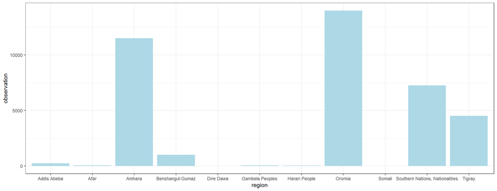

```r
pts_joined |> ggplot(aes(NAME_1))+
  geom_bar(fill = "lightblue")+
  xlab("region")+
  ylab("observation")+
  theme_bw()
```

Number of data per crop

```r
crop <- count(as_tibble(pts_joined), crop)
head(crop, 3)
```

```
## # A tibble: 3 × 2
##   crop            n
##   <chr>       <int>
## 1 barley       3197
## 2 bread wheat   498
## 3 chickpea       30
```

Plot the crop data

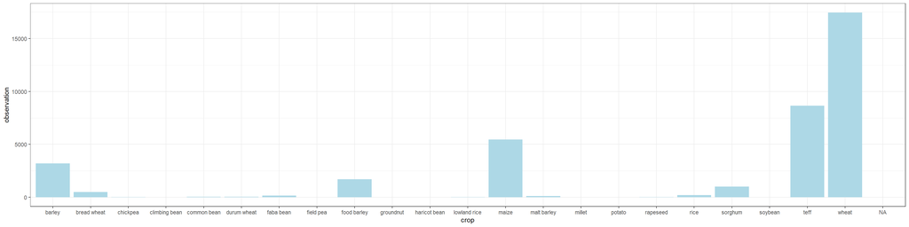

```r
pts_joined |> ggplot(aes(crop))+
  geom_bar(fill = "lightblue")+
  xlab("crop")+
  ylab("observation")+
  theme_bw()
```

Plot data collected in different year

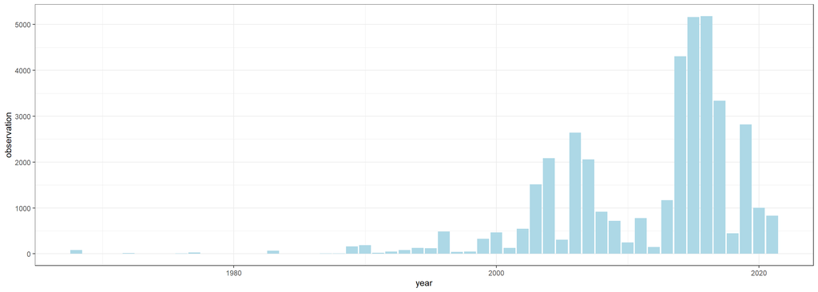

```r
pts_joined |> ggplot(aes(year))+
  geom_bar(fill = "lightblue")+
  xlab("year")+
  ylab("observation")+
  theme_bw()
```

See the total number of unique observations per coordinates

```r
unq_pts <- data_subset |> distinct(long, lat)
dim(unq_pts)[1]
```

```
## [1] 4119
```

Let’s plot the distinct points on the map

```r
pts_dist = st_as_sf(unq_pts, coords = c("long", "lat"), crs = "EPSG:4326")
head(pts_dist)
```

```
## Simple feature collection with 6 features and 0 fields
## Geometry type: POINT
## Dimension:     XY
## Bounding box:  xmin: 39.6572 ymin: 11.3652 xmax: 39.6764 ymax: 11.3766
## Geodetic CRS:  WGS 84
##                  geometry
## 1  POINT (39.6764 11.369)
## 2 POINT (39.6641 11.3652)
## 3 POINT (39.6634 11.3716)
## 4 POINT (39.6594 11.3707)
## 5 POINT (39.6661 11.3766)
## 6 POINT (39.6572 11.3731)
```

Let’s map the points in each region

```r
pts_dist_joined = st_join(eth_reg, pts_dist)
```

Summarize the data based on each region

```r
pts_dist_summ = pts_dist_joined |>
  group_by(NAME_1) |>
  summarise(n = n())
pts_dist_summ
```

```
## Simple feature collection with 11 features and 2 fields
## Geometry type: POLYGON
## Dimension:     XY
## Bounding box:  xmin: 33.00154 ymin: 3.398823 xmax: 47.95823 ymax: 14.84548
## Geodetic CRS:  WGS 84
## # A tibble: 11 × 3
##    NAME_1                              n                                geometry
##    <chr>                           <int>                           <POLYGON [°]>
##  1 Addis Abeba                         1 ((38.87349 8.923755, 38.86807 8.927619…
##  2 Afar                                3 ((40.16169 8.948584, 40.16989 8.964499…
##  3 Amhara                           1594 ((39.74024 9.039542, 39.74368 9.048001…
##  4 Benshangul-Gumaz                   13 ((34.88778 9.908214, 34.90442 9.955878…
##  5 Dire Dawa                           1 ((41.92615 9.66806, 41.90614 9.679303,…
##  6 Gambela Peoples                     4 ((35.19947 6.410904, 35.18663 6.444274…
##  7 Harari People                       2 ((42.26614 9.365982, 42.26127 9.373512…
##  8 Oromia                           1068 ((39.43182 3.853039, 39.48285 3.941999…
##  9 Somali                              1 ((39.63146 4.402709, 39.61882 4.368469…
## 10 Southern Nations, Nationalities   589 ((36.82848 4.709175, 36.85474 4.73606,…
## 11 Tigray                            832 ((39.34235 12.3007, 39.35015 12.29841,…
```

Map the unique points where n is no of observations

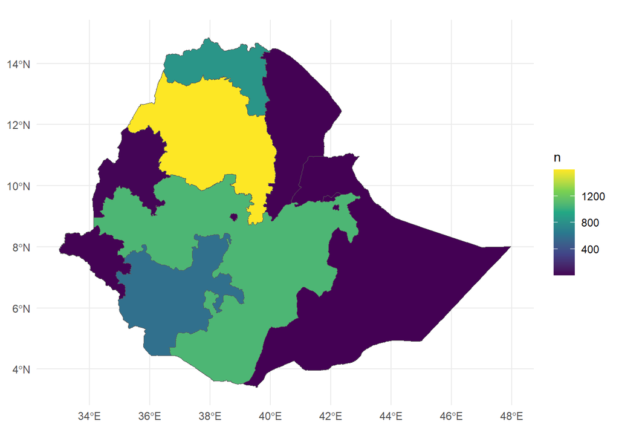

```r
pts_dist_summ |>
  ggplot() +
    geom_sf(fill = "grey80", color = "black") +
    geom_sf(data = pts_dist_summ, aes(fill = n)) +
    scale_fill_viridis_c() +
    theme_minimal()
```

### 5. Remove the NAs and duplicates in each variable

```r
data_filtered <- data_subset |> na.omit() |> unique()
head(data_filtered,3)
```

```
##      long    lat       source region    crop year n p        k  s grain_yield
## 1 39.6764 11.369 AfricaRising Amhara sorghum 2017 0 0  0.00000 20      1497.8
## 2 39.6764 11.369 AfricaRising Amhara sorghum 2017 0 0  0.00000 40      1237.3
## 3 39.6764 11.369 AfricaRising Amhara sorghum 2017 0 0 33.05785  0      1693.8
```

view the dimension of the filtered data

```r
dim(data_filtered)
```

```
## [1] 23089    11
```

Now let’s join the filtered data points by each region

```r
pts_filtered = st_as_sf(data_filtered, coords = c("long", "lat"), crs = "EPSG:4326")
pts_joined_filtered = st_join(eth_reg, pts_filtered)
head(pts_joined_filtered,3)
```

```
## Simple feature collection with 3 features and 20 fields
## Geometry type: POLYGON
## Dimension:     XY
## Bounding box:  xmin: 38.6394 ymin: 8.833486 xmax: 38.90624 ymax: 9.098195
## Geodetic CRS:  WGS 84
##       GID_1 GID_0  COUNTRY      NAME_1                        VARNAME_1
## 1   ETH.1_1   ETH Ethiopia Addis Abeba Āddīs Ābaba|Addis Ababa|Adis-Abe
## 1.1 ETH.1_1   ETH Ethiopia Addis Abeba Āddīs Ābaba|Addis Ababa|Adis-Abe
## 1.2 ETH.1_1   ETH Ethiopia Addis Abeba Āddīs Ābaba|Addis Ababa|Adis-Abe
##     NL_NAME_1    TYPE_1 ENGTYPE_1 CC_1 HASC_1 ISO_1             source region
## 1        <NA> Astedader      City   14  ET.AA  <NA> Geleto et al. 1997 Oromia
## 1.1      <NA> Astedader      City   14  ET.AA  <NA> Geleto et al. 1997 Oromia
## 1.2      <NA> Astedader      City   14  ET.AA  <NA> Geleto et al. 1997 Oromia
##       crop year   n  p k    s grain_yield                       geometry
## 1   barley 1991  60 10 0 14.4        1660 POLYGON ((38.87945 8.918314...
## 1.1 barley 1991 120 10 0 28.8        1800 POLYGON ((38.87945 8.918314...
## 1.2 barley 1991  60 10 0 14.4        1650 POLYGON ((38.87945 8.918314...
```

Plot the data by region

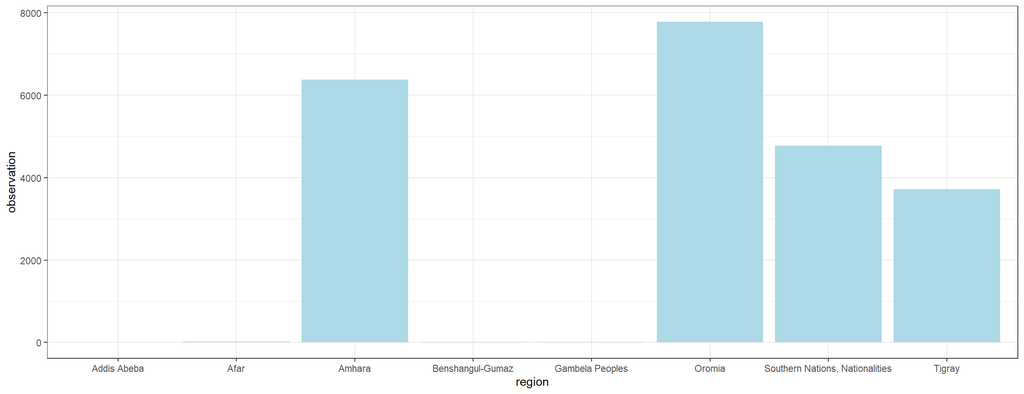

```r
pts_joined_filtered |> filter(!is.na(region)) |> ggplot(aes(NAME_1))+
  geom_bar(fill = "lightblue")+
  xlab("region")+
  ylab("observation")+
  theme_bw()
```

Plot the data by crop

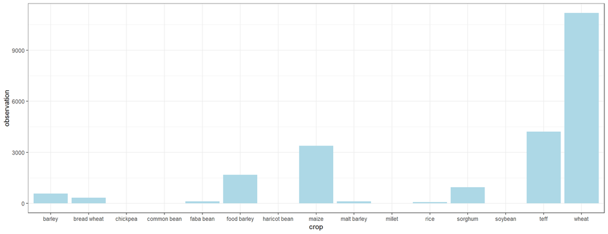

```r
pts_joined_filtered |> filter(!is.na(crop)) |> ggplot(aes(crop))+
  geom_bar(fill = "lightblue")+
  xlab("crop")+
  ylab("observation")+
  theme_bw()
```

Plot the data by year

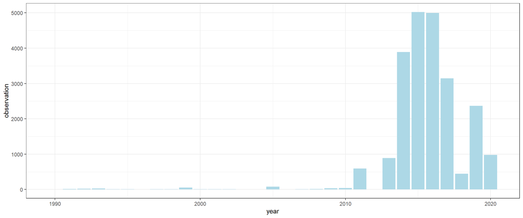

```r
pts_joined_filtered |> filter(!is.na(year)) |> ggplot(aes(year))+
  geom_bar(fill = "lightblue")+
  xlab("year")+
  ylab("observation")+
  theme_bw()
```

Let’s check the total number of unique observations per coordinates for the filtered data

```r
unq_pts_filtered <- data_filtered |> distinct(long, lat)
dim(unq_pts_filtered)[1]
```

```
## [1] 3515
```

Let’s plot the unique points on the map

```r
pts_dist_filtered = st_as_sf(unq_pts_filtered, coords = c("long", "lat"), crs = "EPSG:4326")
head(pts_dist_filtered)
```

```
## Simple feature collection with 6 features and 0 fields
## Geometry type: POINT
## Dimension:     XY
## Bounding box:  xmin: 39.6572 ymin: 11.3652 xmax: 39.6764 ymax: 11.3766
## Geodetic CRS:  WGS 84
##                  geometry
## 1  POINT (39.6764 11.369)
## 2 POINT (39.6641 11.3652)
## 3 POINT (39.6634 11.3716)
## 4 POINT (39.6594 11.3707)
## 5 POINT (39.6661 11.3766)
## 6 POINT (39.6572 11.3731)
```

Lets map the points in each region

```r
pts_dist_joined_filt = st_join(eth_reg, pts_dist_filtered)
```

summarize the data based on each region

```r
pts_dist_summ_filt = pts_dist_joined_filt |>
  group_by(NAME_1) |>
  summarise(n = n())
pts_dist_summ_filt
```

```
## Simple feature collection with 11 features and 2 fields
## Geometry type: POLYGON
## Dimension:     XY
## Bounding box:  xmin: 33.00154 ymin: 3.398823 xmax: 47.95823 ymax: 14.84548
## Geodetic CRS:  WGS 84
## # A tibble: 11 × 3
##    NAME_1                              n                                geometry
##    <chr>                           <int>                           <POLYGON [°]>
##  1 Addis Abeba                         1 ((38.87349 8.923755, 38.86807 8.927619…
##  2 Afar                                2 ((40.16169 8.948584, 40.16989 8.964499…
##  3 Amhara                           1372 ((39.74024 9.039542, 39.74368 9.048001…
##  4 Benshangul-Gumaz                    5 ((34.88778 9.908214, 34.90442 9.955878…
##  5 Dire Dawa                           1 ((41.92615 9.66806, 41.90614 9.679303,…
##  6 Gambela Peoples                     2 ((35.19947 6.410904, 35.18663 6.444274…
##  7 Harari People                       1 ((42.26614 9.365982, 42.26127 9.373512…
##  8 Oromia                            833 ((39.43182 3.853039, 39.48285 3.941999…
##  9 Somali                              1 ((39.63146 4.402709, 39.61882 4.368469…
## 10 Southern Nations, Nationalities   472 ((36.82848 4.709175, 36.85474 4.73606,…
## 11 Tigray                            816 ((39.34235 12.3007, 39.35015 12.29841,…
```

Map the unique points of filtered data where n is no of observations

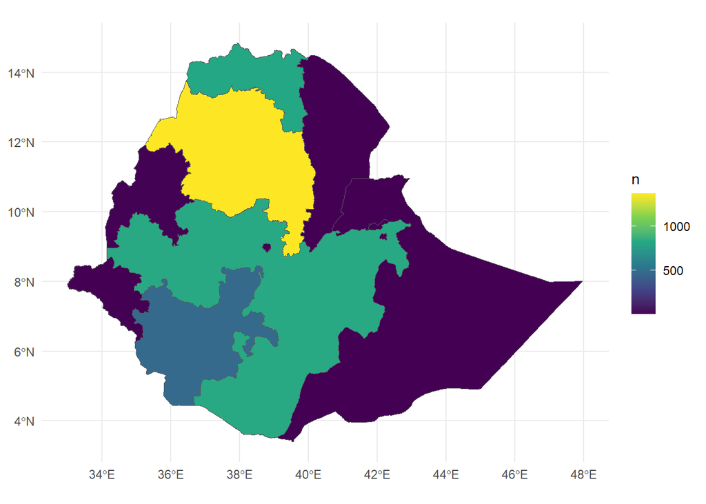

```r
pts_dist_summ_filt |>
  ggplot() +
    geom_sf(fill = "grey80", color = "black") +
    geom_sf(data = pts_dist_summ_filt, aes(fill = n)) +
    scale_fill_viridis_c() +
    theme_minimal()
```

Now lets see the number of unique observations of each crop by year and location

```r
unq_pts_crop <- data_filtered |> group_by(crop) |> distinct(long, lat, year)
unq_pts_crop
```

```
## # A tibble: 5,632 × 4
## # Groups:   crop [15]
##    crop     long   lat  year
##    <chr>   <dbl> <dbl> <int>
##  1 sorghum  39.7  11.4  2017
##  2 sorghum  39.7  11.4  2017
##  3 sorghum  39.7  11.4  2017
##  4 sorghum  39.7  11.4  2017
##  5 sorghum  39.7  11.4  2017
##  6 sorghum  39.7  11.4  2017
##  7 sorghum  39.7  11.4  2017
##  8 sorghum  39.7  11.4  2017
##  9 sorghum  39.7  11.4  2017
## 10 sorghum  39.6  11.7  2017
## # ℹ 5,622 more rows
```

Plot the crop data by unique year lat and long

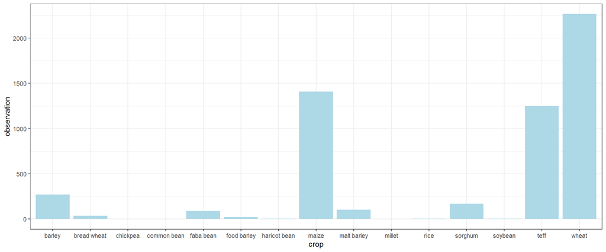

```r
unq_pts_crop |> filter(!is.na(crop)) |> ggplot(aes(crop))+
  geom_bar(fill = "lightblue")+
  xlab("crop")+
  ylab("observation")+
  theme_bw()
```

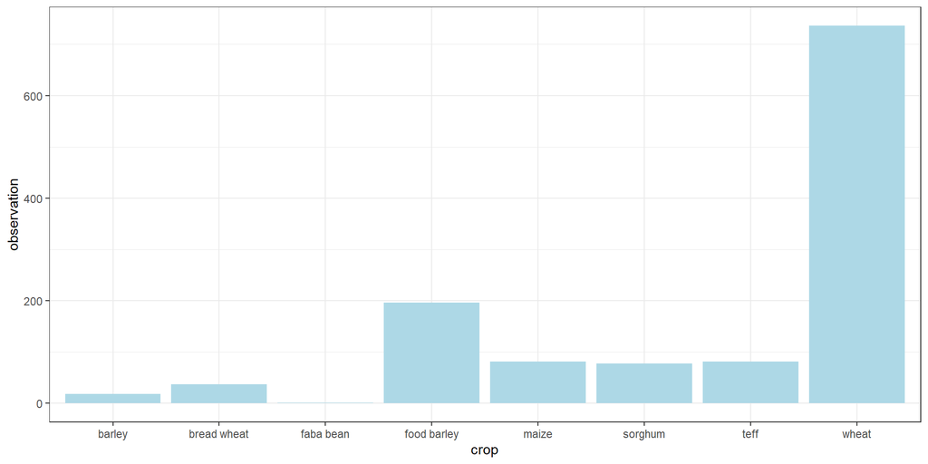

```r
data_filtered |> filter(n == 0 & p == 0 & k == 0) |> ggplot(aes(crop))+
  geom_bar(fill = "lightblue")+
  xlab("crop")+
  ylab("observation")+
  theme_bw()
```